# Taipei_2019_July_cn

## 資料描述

Airbnb自2008年起，建起了一個平台，給國內外遊客另一個由當地住戶提供房源的住宿選擇，有別於飯店與度假村。此次分析的資料來源於Airbnb開放給大眾的數據庫網頁，excel檔中包含關於房東、地理位置、房屋類型...等一些所需資料

## 數據初步處理

#### 1.數據清洗 (data clean)

```
1)檢查重複值
2)列出空值
3)移除多餘欄位
```

#### 2.數據探查（data exploration）

```
1)各個欄位的統計資料
2)變數間的相關係數
```

## 數據可視化及分析

#### 1. 區域

```
1)房源的地區分佈比較（數目及百分比）
2)地圖上房源的區域分佈
3)熱力圖與房源的密度
```

#### 2. 房源價格與區域

```
1)初步統計數字
2)房源價格在區域的變化
3)價格在地圖上的分佈
```

#### 3.房間類型

```
1)房屋類型的數量比較
2)過剩的房源—公寓與房屋
```

#### 4.最少居住天數:房源提供給旅遊者與長租客的比例

```
1)最少居住天數的數量分布
2)最少居住天數的累計百分比
3)短租旅遊市場過剩的房源類型(最少居住14天以下的房間類型數量分佈)
4)住的天數越少，價格越高嗎?
```

#### 5.房東是家庭戶還是仲介？

```
1)家庭戶與仲介的數量與比例
```

#### 6.房源流失

```
1)流失房源的區域、最少天數、房型
```

#### 7.出租的房源

```
1)出租房源的區域、最少天數、房型
2)出租房源的價格
```

#### 8.文字雲

```
1)房源標題關鍵字
2)點閱數與房源標題關鍵字
```

```python
import pandas as pd
df=pd.read_csv("listingsRoc.csv")
df.head(5)
```

|  | id | name | host_id | host_name | neighbourhood_group | neighbourhood | latitude | longitude | room_type | price | minimum_nights | number_of_reviews | last_review | reviews_per_month | calculated_host_listings_count | availability_365 |
| --- | --- | --- | --- | --- | --- | --- | --- | --- | --- | --- | --- | --- | --- | --- | --- | --- |
| 0 | 68396 | Zhongxiao Dunhua Studio C near MRT | 339014 | Lisa | NaN | 大安區 | 25.04258 | 121.55365 | Entire home/apt | 1555 | 7 | 2 | 2018-06-20 | 0.03 | 12 | 305 |
| 1 | 68398 | Tonghua Vacation Studio C | 339014 | Lisa | NaN | 大安區 | 25.02925 | 121.55561 | Entire home/apt | 933 | 30 | 7 | 2019-04-01 | 0.09 | 12 | 317 |
| 2 | 74641 | 黑白雙人房@南京復興站｡小巨蛋斜對面｡溫泉式浴缸｡ | 393116 | Yi-Wan | NaN | 松山區 | 25.05159 | 121.54747 | Private room | 1555 | 3 | 48 | 2019-05-05 | 0.51 | 4 | 63 |
| 3 | 74643 | 小巨蛋｡南京復興站溫馨套房 | 393116 | Yi-Wan | NaN | 松山區 | 25.05067 | 121.54568 | Private room | 1306 | 2 | 51 | 2019-06-09 | 0.50 | 4 | 70 |
| 4 | 178036 | 單人床位 Single bunk bed [mixed dorm for 4pax] | 851825 | TaipeiTaipei Hostel | NaN | 中正區 | 25.04488 | 121.51305 | Shared room | 404 | 1 | 60 | 2019-07-24 | 0.62 | 9 | 343 |

### 欄位描述

id:貼文編號  
name:房源標題名稱  
host_id:房東編號  
host_name:房東名稱  
neighbourhood_group:地點  
neighbourhood:地區  
room_type:房型  
minimum_nights:最少居住天數  
number_of_reviews:此出租房源瀏覽的次數  
last_review:此出租房源上次被瀏覽的日期  
reviews_per_month:此出租房源每月瀏覽的次數  
calculated_host_listings_count:房東釋出的房源數目  
availability_365:一年中房源可提供出租的天數

### 查看各個欄位的資料類型

```python
df.dtypes,len(df)
```

```
(id                                  int64
 name                               object
 host_id                             int64
 host_name                          object
 neighbourhood_group               float64
 neighbourhood                      object
 latitude                          float64
 longitude                         float64
 room_type                          object
 price                               int64
 minimum_nights                      int64
 number_of_reviews                   int64
 last_review                        object
 reviews_per_month                 float64
 calculated_host_listings_count      int64
 availability_365                    int64
 dtype: object, 9937)
```

# 數據清洗

```python
df.duplicated().sum()
```

```
0
```

```python
df.isnull().sum(),len(df)
```

```
(id                                   0
 name                                 5
 host_id                              0
 host_name                            3
 neighbourhood_group               9937
 neighbourhood                        0
 latitude                             0
 longitude                            0
 room_type                            0
 price                                0
 minimum_nights                       0
 number_of_reviews                    0
 last_review                       1966
 reviews_per_month                 1966
 calculated_host_listings_count       0
 availability_365                     0
 dtype: int64, 9937)
```

各個欄位中沒有重複值，neighbourhood_group全部都是空的，先刪除這個欄位  
name及host_name有少數空值，此次分析中不會用到，暫不處理

```python
df.drop(['neighbourhood_group'],axis=1,inplace=True)
```

```python
#df.to_csv('taipei_excelUse.csv',encoding='utf_8_sig',index=False)
```

# 數據探查

```python
#import pandas_profiling
#df.profile_report()
```

**last_review 空值代表此房源可能關閉，不提供出租，所以沒有上次瀏覽日期。先刪除這部分的資料，查看真正有在平台上運作的房源數目是 **7971** 個**

```python
df=df[df['last_review'].isnull().values==False]
len(df)
```

```
7971
```

### 變數間的相關係數

1. 中等正相關(0.5~0.75): 房東編號及貼文編號(0.53), 瀏覽次數及每個月瀏覽次數(0.62)
2. 負弱相關(-0.3~-0.5):貼文編號及瀏覽次數(-0.42)
3. **由於變數呈現偏態分佈，而非正態分佈，因此相關係數能參考的價值不多...**

```python
df.drop(['neighbourhood'],axis=1).corr().style.background_gradient(cmap='coolwarm')
```

|  | id | host_id | latitude | longitude | price | minimum_nights | number_of_reviews | reviews_per_month | calculated_host_listings_count | availability_365 |
| --- | --- | --- | --- | --- | --- | --- | --- | --- | --- | --- |
| id | 1 | 0.538794 | -0.051458 | -0.0976184 | -0.0314783 | -0.0366152 | -0.422602 | 0.181172 | 0.0295954 | -0.145853 |
| host_id | 0.538794 | 1 | -0.00221648 | -0.0384928 | -0.0159605 | -0.0195663 | -0.221986 | 0.114076 | -0.0441602 | -0.0832159 |
| latitude | -0.051458 | -0.00221648 | 1 | -0.142155 | 0.0218681 | 0.0037905 | 0.00563481 | -0.0258129 | -0.0852001 | 0.0575566 |
| longitude | -0.0976184 | -0.0384928 | -0.142155 | 1 | 0.0241273 | 0.0210558 | 0.00128835 | -0.0856492 | -0.140929 | -0.0529864 |
| price | -0.0314783 | -0.0159605 | 0.0218681 | 0.0241273 | 1 | 0.00603218 | -0.0261184 | -0.0396049 | -0.0216765 | 0.0169615 |
| minimum_nights | -0.0366152 | -0.0195663 | 0.0037905 | 0.0210558 | 0.00603218 | 1 | -0.0353186 | -0.0575473 | 0.0126488 | 9.90699e-05 |
| number_of_reviews | -0.422602 | -0.221986 | 0.00563481 | 0.00128835 | -0.0261184 | -0.0353186 | 1 | 0.62764 | -0.118994 | 0.0115399 |
| reviews_per_month | 0.181172 | 0.114076 | -0.0258129 | -0.0856492 | -0.0396049 | -0.0575473 | 0.62764 | 1 | -0.117706 | -0.0863249 |
| calculated_host_listings_count | 0.0295954 | -0.0441602 | -0.0852001 | -0.140929 | -0.0216765 | 0.0126488 | -0.118994 | -0.117706 | 1 | 0.0169415 |
| availability_365 | -0.145853 | -0.0832159 | 0.0575566 | -0.0529864 | 0.0169615 | 9.90699e-05 | 0.0115399 | -0.0863249 | 0.0169415 | 1 |

## 房源的地區分佈比較

萬華區,大安區,中正區及中山區都超過1000個房源，分別佔房源總數的10%以上，尤其以萬華最多，佔房源總數的1/4

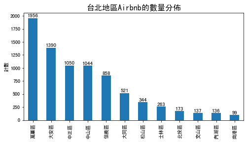

```python
import matplotlib.pyplot as plt
plt.rcParams['font.sans-serif']=['SimHei']
plt.rcParams['axes.unicode_minus']=False

ser_area=df['neighbourhood'].value_counts()
plt.figure(figsize=(8,4))
ser_area.plot.bar()
for x,y in enumerate(ser_area):
    plt.text(x, y+5, '%.0f' % y, ha='center', va= 'bottom',fontsize=11)
plt.title('台北地區Airbnb的數量分佈',fontsize=16)
plt.ylabel('計數')
plt.show()
```

**台北地區Airbnb的數量百分比**

```python
(ser_area/ser_area.sum()).apply(lambda x:format(x,'.0%'))
```

```
萬華區    25%
大安區    17%
中正區    13%
中山區    13%
信義區    11%
大同區     7%
松山區     4%
士林區     3%
北投區     2%
文山區     2%
內湖區     2%
南港區     1%
Name: neighbourhood, dtype: object
```

### ✦地圖上房源的區域分佈

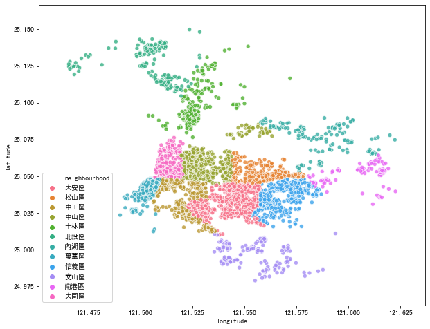

```python
import seaborn as sns
plt.figure(figsize=(10,8))
sns.scatterplot(data=df,x='longitude',y='latitude',hue='neighbourhood',cmap=plt.get_cmap('jet'),alpha=0.8)
plt.ioff()
```

### ✦ 熱力圖與房源的密度

高密度為紅色，低密度為藍色

```python
import folium
from folium.plugins import HeatMap
m=folium.Map([df['latitude'].median(), df['longitude'].median()],zoom_start=11.5)
HeatMap(df[['latitude','longitude']].dropna(),radius=8,gradient={0.2:'blue',0.4:'purple',0.6:'orange',1.0:'red'}).add_to(m)
display(m)
```

[interactive chart not shown]

## 房源價格與區域

### ✦ 初步統計數字

**1. 所有地區的最低價格都很相似，介於300-400之間**

```python
PriceStat=df['price'].groupby(df['neighbourhood']).describe()
PriceStat['range']=PriceStat['max']-PriceStat['min']
PriceStat['cv']=PriceStat['std']/PriceStat['mean']
PriceStat
#PriceStat.to_csv("PriceStat.csv",encoding='utf_8_sig')
```

| neighbourhood | count | mean | std | min | 25% | 50% | 75% | max | range | cv |
| --- | --- | --- | --- | --- | --- | --- | --- | --- | --- | --- |
| 中山區 | 1044.0 | 2145.499042 | 4851.148087 | 311.0 | 1088.0 | 1492.0 | 2114.00 | 99992.0 | 99681.0 | 2.261081 |
| 中正區 | 1050.0 | 1762.820000 | 1351.346491 | 311.0 | 964.0 | 1399.0 | 2176.00 | 12996.0 | 12685.0 | 0.766582 |
| 信義區 | 858.0 | 3193.505828 | 15126.030084 | 311.0 | 1119.0 | 1803.0 | 2985.00 | 310919.0 | 310608.0 | 4.736497 |
| 內湖區 | 136.0 | 2627.014706 | 4712.865377 | 311.0 | 902.0 | 1492.0 | 2370.75 | 43529.0 | 43218.0 | 1.794000 |
| 北投區 | 173.0 | 3328.965318 | 22717.030892 | 311.0 | 746.0 | 1181.0 | 2052.00 | 299913.0 | 299602.0 | 6.824052 |
| 南港區 | 99.0 | 1265.353535 | 921.088135 | 311.0 | 591.0 | 995.0 | 1710.00 | 5565.0 | 5254.0 | 0.727929 |
| 士林區 | 263.0 | 1633.235741 | 2446.707833 | 373.0 | 902.0 | 1213.0 | 1772.00 | 36160.0 | 35787.0 | 1.498074 |
| 大同區 | 521.0 | 2600.378119 | 13182.160486 | 342.0 | 995.0 | 1524.0 | 2487.00 | 300006.0 | 299664.0 | 5.069324 |
| 大安區 | 1390.0 | 2171.710791 | 2175.833294 | 311.0 | 995.0 | 1555.0 | 2612.00 | 30874.0 | 30563.0 | 1.001898 |
| 文山區 | 137.0 | 1795.364964 | 2208.061759 | 311.0 | 871.0 | 1275.0 | 1897.00 | 19992.0 | 19681.0 | 1.229868 |
| 松山區 | 344.0 | 2671.773256 | 16189.915743 | 342.0 | 995.0 | 1368.0 | 2176.00 | 300970.0 | 300628.0 | 6.059614 |
| 萬華區 | 1956.0 | 1938.046524 | 1467.702597 | 311.0 | 1213.0 | 1555.0 | 2208.00 | 24998.0 | 24687.0 | 0.757310 |

**2.最貴的房源在信義區，然後是松山及大同，三個地方都在30萬以上**

```python
PriceStat['max'].sort_values(ascending=False).head(5)
```

```
neighbourhood
信義區    310919.0
松山區    300970.0
大同區    300006.0
北投區    299913.0
中山區     99992.0
Name: max, dtype: float64
```

**3.價格範圍落差最大仍是信義、松山、大同**

```python
PriceStat['range'].sort_values(ascending=False).head(5)
```

```
neighbourhood
信義區    310608.0
松山區    300628.0
大同區    299664.0
北投區    299602.0
中山區     99681.0
Name: range, dtype: float64
```

### ✦ 房源價格在區域的變化

**1. 由cv欄計算出的變異係數得知，中正、南港、萬華的價格變化較小，變異係數小於1，相較於其他地區都是大於;價格差異最大的為北投及松山地區都超過6**

```python
PriceStat['cv'].sort_values()
```

```
neighbourhood
南港區    0.727929
萬華區    0.757310
中正區    0.766582
大安區    1.001898
文山區    1.229868
士林區    1.498074
內湖區    1.794000
中山區    2.261081
信義區    4.736497
大同區    5.069324
松山區    6.059614
北投區    6.824052
Name: cv, dtype: float64
```

2.因為高價數目少，且多為離群值，小提琴圖去除前25%的價格  
3.在500-1000價格分佈較多的是北投、南港、內湖區，其他地區房源價格多落在1000-1500

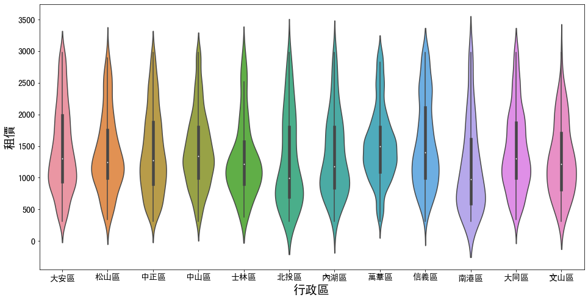

```python
df_3000=df[df['price']<3000]
plt.rcParams['font.sans-serif']=['SimHei']
plt.figure(figsize=(16,8))
sns.violinplot(data=df_3000,x='neighbourhood',y='price')
plt.xlabel('行政區',fontsize=20)
plt.ylabel('租價',fontsize=20)
plt.xticks(fontsize=14)
plt.yticks(fontsize=14)
plt.show()
```

### ✦ 價格在地圖上的分佈

[figure not shown]

```python
import urllib
plt.figure(figsize=(10,10))
i=urllib.request.urlopen('https://images2.imgbox.com/2c/ae/mMEmrRaN_o.png')
nyc_img=plt.imread(i)
plt.figure(figsize=(10,8))
plt.imshow(nyc_img,zorder=0,extent=[121.45, 121.65, 24.95,25.175])
ax=plt.gca()
plt.figure(figsize=(10,10))
df_3000.plot(kind='scatter',x='longitude',y='latitude',c='price',cmap=plt.get_cmap('jet'),colorbar=True,alpha=0.4,ax=ax)
plt.show()
```

## 房間類型

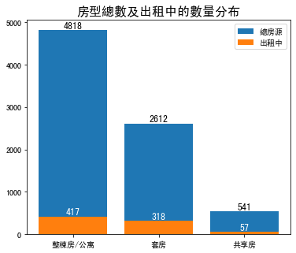

```python
allroom=df['room_type'].value_counts()

plt.figure(figsize=(6,5))
plt.bar(x=allroom.index,height=allroom.values,label='總房源')
for x,y in enumerate(allroom):
    plt.text(x, y+5, '%.0f' % y, ha='center', va= 'bottom',fontsize=12)
rent=df[df['availability_365'].values==0]
rent=rent['room_type'].value_counts()
plt.bar(x=allroom.index,height=rent.values, label='出租中')
for x,y in enumerate(rent):
    plt.text(x, y+5, '%.0f' % y, ha='center', va= 'bottom',fontsize=12,color='w')

#rentRate=rent/allroom*100
#for x,y in enumerate(renrRate):
#    plt.text(x, y,'%.0f%%' % y, ha='center', va= 'bottom',fontsize=12,color='w')
plt.legend()
plt.title('房型總數及出租中的數量分布',fontsize=16)
ax = plt.gca()
ax.set_xticklabels(["整棟房/公寓","套房","共享房"])
plt.show()
```

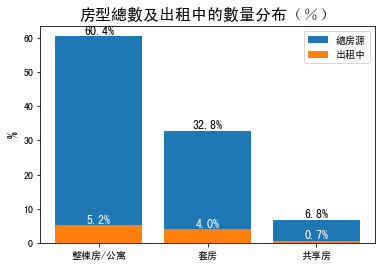

```python
allroomRate=(allroom/allroom.sum())*100
plt.bar(allroomRate.index,allroomRate.values,label='總房源')
for x,y in enumerate(allroomRate):
    plt.text(x, y, '%.1f%%' % y, ha='center', va= 'bottom',fontsize=12)
rentRate=rent/allroom.sum()*100
plt.bar(allroomRate.index,rentRate.values,label='出租中')
for x,y in enumerate(rentRate):
    plt.text(x, y, '%.1f%%' % y, ha='center', va= 'bottom',fontsize=12,color='w')
plt.legend()
plt.title('房型總數及出租中的數量分布（％）',fontsize=16)
plt.ylabel('%',fontsize=14)
ax = plt.gca()
ax.set_xticklabels(["整棟房/公寓","套房","共享房"])
plt.show()
```

**查看出租的公寓及房屋中的最少需租天數，發現租1-2天的短期旅遊房客在250多人;而長租的房客（30天以上）只有8位。顯示家庭旅遊的人比長租客多很多，對租公寓及房屋的需求也不小**

```python
df[(df['availability_365'].values==0)&(df['room_type']=="Entire home/apt")]['minimum_nights'].value_counts().sort_index()
```

```
1     153
2     100
3      37
4       4
5       8
7       2
14      2
16      1
20      1
28      1
29      1
30      7
90      1
Name: minimum_nights, dtype: int64
```

## 最少居住天數:房源提供給旅遊者與長租客的比例

1. 最少居住1-2天數有壓倒性的數目，佔全部的85%;兩個星期以下佔全部的96%,只有4%的房源是給超過兩星期的旅客。
2. 至少住30天，在數量上突然地增加到200，至少住一年以上的有7個房源，總體上有200多個房源是歡迎長租客的

```python
NightCount=df['minimum_nights'].value_counts().sort_index()
```

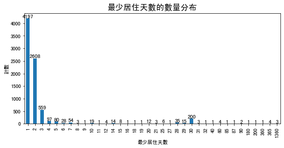

```python
plt.figure(figsize=(9,4))
#plt.figure()
NightCount.plot.bar()
for x,y in enumerate(NightCount):
    plt.text(x, y, '%.0f' % y, ha='center', va= 'bottom',fontsize=11)
plt.xlabel('最少居住天數')
plt.ylabel('計數')
plt.title('最少居住天數的數量分布',fontsize=16)
plt.show()
```

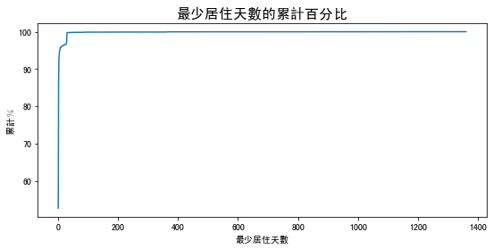

```python
NightCountRate=NightCount.cumsum()/NightCount.sum()*100
plt.figure(figsize=(9,4))
plt.plot(NightCount.index,NightCountRate.values)
plt.xlabel('最少居住天數')
plt.ylabel('累計％')
plt.title('最少居住天數的累計百分比',fontsize=16)
plt.show()
```

最少居住天數的前15天的累計百分比

```python
NightCountRate=NightCount.cumsum()/NightCount.sum()
NightCountRate=NightCountRate.apply(lambda x:format(x,'.1%'))
NightCountRate.head(14)
```

```
1     52.7%
2     85.4%
3     92.4%
4     93.6%
5     94.6%
6     95.0%
7     95.6%
8     95.7%
9     95.7%
10    95.9%
11    95.9%
12    96.0%
14    96.2%
15    96.3%
Name: minimum_nights, dtype: object
```

### 短租旅遊市場過剩的房源類型

1.由上分析，有96％(7651個)的房源最少居住天在14天以下，公寓及房屋出租的房源幾乎是套房的兩倍，但套房的出租數量高過公寓及房屋快100，顯示套房在短租旅市場中仍是最受歡迎的  
2.而Airbnb仍有4335個公寓及房屋的房源是待租的，顯示過多的供給與空屋率

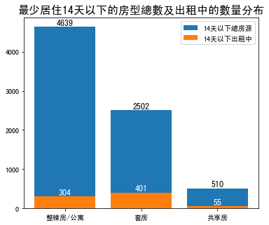

```python
less14=df[df['minimum_nights']<14].groupby('room_type')['id'].count()

plt.figure(figsize=(6,5))
plt.bar(x=less14.index,height=less14.values,label='14天以下總房源')
for x,y in enumerate(less14):
    plt.text(x, y+5, '%.0f' % y, ha='center', va= 'bottom',fontsize=12)

less14rent=df[(df['availability_365'].values==0)&(df['minimum_nights']<14)].groupby('room_type')['id'].count()
plt.bar(x=less14.index,height=less14rent.values, label='14天以下出租中')
for x,y in enumerate(less14rent):
    plt.text(x, y+5, '%.0f' % y, ha='center', va= 'bottom',fontsize=12,color='w')
plt.legend()
plt.title('最少居住14天以下的房型總數及出租中的數量分布',fontsize=16)
ax = plt.gca()
ax.set_xticklabels(["整棟房/公寓","套房","共享房"])
plt.show()
```

### 住的天數越少，價格越高？

1.從散點圖看不出來明顯的關係，將數據以最低天數分割，看價格與房間的相關係數

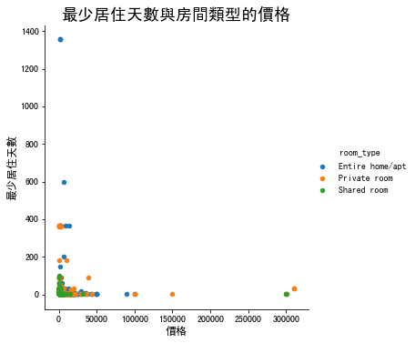

```python
plt.figure(figsize=(15,15))
sns.FacetGrid(df,hue='room_type',size=5).map(plt.scatter,'price','minimum_nights',s=20).add_legend()
plt.title('最少居住天數與房間類型的價格', {"fontsize" : 18})
plt.xlabel('價格',fontsize=12)
plt.ylabel('最少居住天數',fontsize=12)
plt.show()
```

2.將最少天數限制在14天以下（旅遊短租），價格與房型的相關係數非常低，其正負值趨近於0的無相關

```python
day14=df[df['minimum_nights']<14]
day14[['price','room_type','minimum_nights']].groupby('room_type').corr()
```

| room_type |  | price | minimum_nights |
| --- | --- | --- | --- |
| Entire home/apt | price | 1.000000 | 0.067769 |
|  | minimum_nights | 0.067769 | 1.000000 |
| Private room | price | 1.000000 | -0.028247 |
|  | minimum_nights | -0.028247 | 1.000000 |
| Shared room | price | 1.000000 | -0.014639 |
|  | minimum_nights | -0.014639 | 1.000000 |

```python
day14more=df[(df['minimum_nights']>=14) & (df['minimum_nights']<60)]
day14more[['price','room_type','minimum_nights']].groupby('room_type').corr()
```

| room_type |  | price | minimum_nights |
| --- | --- | --- | --- |
| Entire home/apt | price | 1.000000 | -0.255324 |
|  | minimum_nights | -0.255324 | 1.000000 |
| Private room | price | 1.000000 | 0.054375 |
|  | minimum_nights | 0.054375 | 1.000000 |
| Shared room | price | 1.000000 | -0.206119 |
|  | minimum_nights | -0.206119 | 1.000000 |

## 房東是家庭戶還是仲介？

```python
print('房東有10個房源以下，共有',len(df[df['calculated_host_listings_count']<10]),
      '，其佔全部房源的比例','%.0f%%' % (len(df[df['calculated_host_listings_count']<10])/len(df)*100))
```

```
房東有10個房源以下，共有 5259 ，其佔全部房源的比例 66%
```

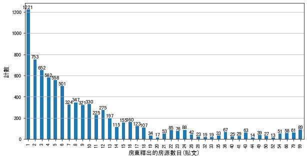

```python
plt.figure(figsize=(10,5))
list=df['calculated_host_listings_count'].value_counts().sort_index()
list.plot.bar()
for x,y in enumerate(list):
    plt.text(x, y+5, '%.0f' % y, ha='center', va= 'bottom',fontsize=11)
plt.xlabel('房東釋出的房源數目(貼文)',fontsize=12)
plt.ylabel('計數',fontsize=12)
plt.grid(axis="y")
plt.show()
```

# 房源流失

✦ 從之前的報告中，一年中房源可提供出租的天數的欄位（availability_365） 有1119 (11.3%) 是0, 若加上無人瀏覽，以及無上次瀏覽資料，Airbnb 很可能流失房源，因為房源關閉或不開放

1. 關閉的房源有 **327** 個,而流失率是 **3.29%**

```python
df=pd.read_csv("listingsRoc.csv")
df0=df[df['availability_365']==0]
losing=df0[df0["last_review"].isnull()]
print('關閉的房源有',len(losing),'其比例','%.2f%%' % (len(losing)/len(df)*100))
```

```
關閉的房源有 327 其比例 3.29%
```

### 流失房源的區域、最少天數、房型

在這327個流失房源中  
1.大安區流失最多，其次是中山、信義區，南港最少  
2.最少居住1天的房源關閉最多  
3.套房流失佔一半

```python
losing=losing['room_type'].replace("Private room","套房").replace('Shared room','共享房').replace("Entire home/apt","整棟房/公寓")
```

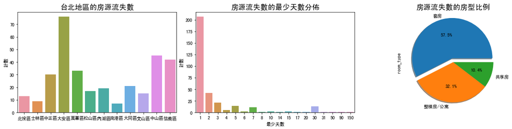

```python
f,ax=plt.subplots(1,3,figsize=(20,4))
plt.subplots_adjust(wspace =0.12)
sns.countplot('neighbourhood',data=losing,ax=ax[0])
ax[0].set_title('台北地區的房源流失數',fontsize=16)
ax[0].set_xlabel('',)
ax[0].set_ylabel('計數')

sns.countplot('minimum_nights',data=losing,ax=ax[1])
ax[1].set_title('房源流失數的最少天數分佈',fontsize=16)
ax[1].set_xlabel('最少天數')
ax[1].set_ylabel('計數')

losing['room_type'].value_counts().plot.pie(explode=[0.1,0,0,],autopct='%1.1f%%',shadow=True,ax=ax[2])
ax[2].set_title('房源流失數的房型比例',fontsize=16)
plt.show()
```

# 出租的房源

出租房源有 **792**， 出租率是 **8%**

```python
onRent=df0[df0['last_review'].isnull().values==False]
print(len(onRent),'%.1f%%' %(len(onRent)/len(df)*100))
```

```
792 8.0%
```

房客至少花費 **22738346** 在住宿上

```python
(onRent['price']*onRent['minimum_nights']).sum()
```

```
22738346
```

### 出租房源的區域、最少天數、房型

1.以大安、中山、中正區最多人租  
2.大多租1-3天，租一個月排第四多  
3.以套房最受歡迎，佔所有出租數目的一半

```python
onRent=onRent['room_type'].replace("Private room","套房").replace('Shared room','共享房').replace("Entire home/apt","整棟房/公寓")
```

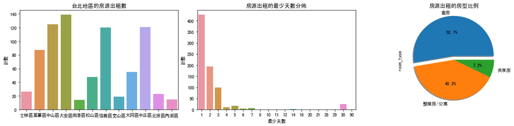

```python
f,ax=plt.subplots(1,3,figsize=(20,4))
plt.subplots_adjust(wspace =0.12)
sns.countplot('neighbourhood',data=onRent,ax=ax[0])
ax[0].set_title('台北地區的房源出租數')
ax[0].set_xlabel('',)
ax[0].set_ylabel('計數')

sns.countplot('minimum_nights',data=onRent,ax=ax[1])
ax[1].set_title('房源出租的最少天數分佈')
ax[1].set_xlabel('最少天數')
ax[1].set_ylabel('計數')

onRent['room_type'].value_counts().plot.pie(explode=[0.1,0,0,],autopct='%1.1f%%',shadow=True,ax=ax[2])
plt.title('房源出租的房型比例')
plt.show()
```

### 出租房源的價格

1.價格由圖表顯示，由於價格太多，不易閱讀，改以統計資料顯示

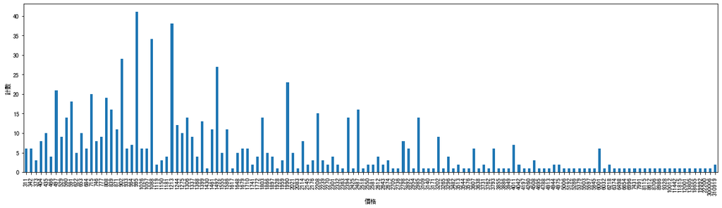

```python
plt.figure(figsize=(20,5))
onRent['price'].value_counts().sort_index().plot.bar()
plt.xlabel('價格')
plt.ylabel('計數')
plt.show()
```

2.由統計資料表格顯示，租金的平均是2995,最多人選擇的租金是995

```python
onRentStat=onRent[['price']].describe().T
onRentStat['mode']=onRent['price'].mode()[0]
onRentStat
```

|  | count | mean | std | min | 25% | 50% | 75% | max | mode |
| --- | --- | --- | --- | --- | --- | --- | --- | --- | --- |
| price | 792.0 | 2995.037879 | 18876.211511 | 311.0 | 871.0 | 1275.0 | 2208.0 | 310919.0 | 995 |

```python
onRent['price'].value_counts().head(10)
```

```
995     41
1213    38
1088    34
902     29
1492    27
1990    23
497     21
715     20
808     19
591     18
Name: price, dtype: int64
```

# 文字雲

1.熱門的出租貼文標題是Taipei,Ximen MRT,MRT...如下圖中，房東期望吸引外地遊客租屋

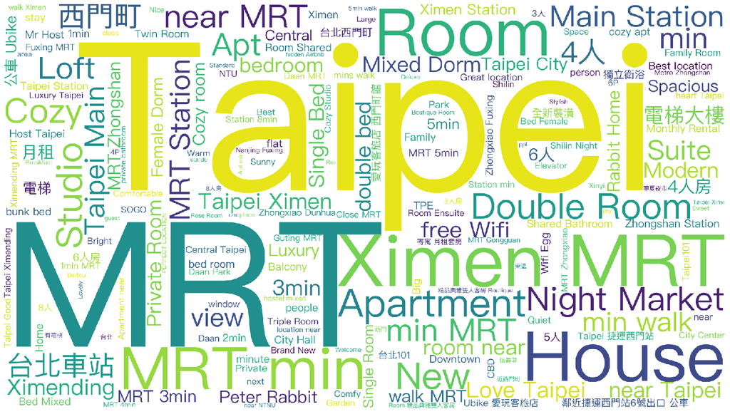

```python
from wordcloud import WordCloud
plt.subplots(figsize=(25,15))
wordcloud = WordCloud(font_path="/System/Library/fonts/PingFang.ttc",background_color='white',width=1920,height=1080).generate(" ".join(df.name.astype('str')))
plt.imshow(wordcloud)
plt.axis('off')
plt.show()
```

2.查看點閱率前10的標題名稱，發現含有Taipei 101的很多

```python
df.sort_values(by=['number_of_reviews'],ascending=False).head(10)
```

|  | id | name | host_id | host_name | neighbourhood_group | neighbourhood | latitude | longitude | room_type | price | minimum_nights | number_of_reviews | last_review | reviews_per_month | calculated_host_listings_count | availability_365 |
| --- | --- | --- | --- | --- | --- | --- | --- | --- | --- | --- | --- | --- | --- | --- | --- | --- |
| 481 | 4382196 | Luxury room with Taipei 101 View | 22752436 | LuLu | NaN | 文山區 | 24.98615 | 121.58782 | Entire home/apt | 2270 | 1 | 515 | 2019-07-29 | 9.00 | 1 | 198 |
| 1432 | 9741230 | #E_ Taipei101 & XiangShan MRT象山夜景 | 7946681 | D&P | NaN | 信義區 | 25.02758 | 121.57455 | Private room | 1119 | 2 | 441 | 2019-07-28 | 9.97 | 7 | 97 |
| 201 | 1911361 | Taipei 101 Wu's Casita | 6378689 | Wei Wei | NaN | 信義區 | 25.03116 | 121.55898 | Private room | 591 | 1 | 430 | 2019-07-14 | 6.30 | 2 | 289 |
| 1906 | 12420893 | #A_TAIPEI101 & XiangShan MRT\|台北象山夜景\|月租Monthly ... | 7946681 | D&P | NaN | 信義區 | 25.02365 | 121.57107 | Private room | 1119 | 2 | 392 | 2019-07-26 | 9.80 | 7 | 57 |
| 1850 | 12162605 | #C_TAIPEI101 & XiangShan MRT\|台北象山夜景\|月租Monthly ... | 7946681 | D&P | NaN | 信義區 | 25.02442 | 121.57071 | Private room | 1181 | 2 | 387 | 2019-07-25 | 9.61 | 7 | 82 |
| 459 | 4161993 | 180-sq.m/1F/City Center/MiDi Room | 21596577 | Y&O | NaN | 中正區 | 25.02859 | 121.51254 | Private room | 933 | 2 | 387 | 2019-07-23 | 6.60 | 1 | 83 |
| 245 | 2211655 | Taipei East District - Single Bed B ❤ Near MRT | 10612177 | Wow | NaN | 大安區 | 25.03950 | 121.54425 | Private room | 839 | 1 | 372 | 2019-07-10 | 5.65 | 4 | 150 |
| 1056 | 7643283 | Casa Ximen 2+1 Taipei 西門春天1 | 30511314 | Jose | NaN | 萬華區 | 25.04502 | 121.50540 | Entire home/apt | 1461 | 1 | 370 | 2019-07-29 | 7.76 | 2 | 220 |
| 1061 | 7671517 | 台北101信義百貨商圈內,MRT出口250m三人房A(機場大巴終站,近饒河夜市,直達宜蘭公車起點) | 24501553 | Kail | NaN | 信義區 | 25.04224 | 121.56639 | Entire home/apt | 1306 | 1 | 361 | 2019-07-26 | 7.45 | 5 | 292 |
| 1122 | 7983272 | Flower Blossom Room | 4278247 | Max | NaN | 大安區 | 25.04242 | 121.54698 | Private room | 995 | 2 | 357 | 2019-07-24 | 7.72 | 6 | 300 |